# Chapter4

The boston data frame has 506 rows and 14 columns, which means that there are 14 variables. crim is per capita crime rate by town; zn is proportion of residential land zoned for lots over 25,000 sq.ft.; indus is the proportion of non-retail business acres per town; chas is Charles River dummy variable (= 1 if tract bounds river; 0 otherwise); nox is nitrogen oxides concentration (parts per 10 million); rm is average number of rooms per dwelling; age is proportion of owner-occupied units built prior to 1940; dis is weighted mean of distances to five Boston employment centres;rad is index of accessibility to radial highways; tax is full-value property-tax rate per $10,000; ptratio is pupil-teacher ratio by town.black is 1000(Bk - 0.63)^2 where Bk is the proportion of blacks by town; lstat means lower status of the population (percent); medv means median value of owner-occupied homes in $1000s.

```r
# access the MASS package
library(MASS)
# load the data
data("Boston")

# center and standardize variables
boston_scaled <- scale(Boston)

# summaries of the scaled variables
summary(boston_scaled)
```

```
##       crim                 zn               indus              chas
##  Min.   :-0.419367   Min.   :-0.48724   Min.   :-1.5563   Min.   :-0.2723
##  1st Qu.:-0.410563   1st Qu.:-0.48724   1st Qu.:-0.8668   1st Qu.:-0.2723
##  Median :-0.390280   Median :-0.48724   Median :-0.2109   Median :-0.2723
##  Mean   : 0.000000   Mean   : 0.00000   Mean   : 0.0000   Mean   : 0.0000
##  3rd Qu.: 0.007389   3rd Qu.: 0.04872   3rd Qu.: 1.0150   3rd Qu.:-0.2723
##  Max.   : 9.924110   Max.   : 3.80047   Max.   : 2.4202   Max.   : 3.6648
##       nox                rm               age               dis
##  Min.   :-1.4644   Min.   :-3.8764   Min.   :-2.3331   Min.   :-1.2658
##  1st Qu.:-0.9121   1st Qu.:-0.5681   1st Qu.:-0.8366   1st Qu.:-0.8049
##  Median :-0.1441   Median :-0.1084   Median : 0.3171   Median :-0.2790
##  Mean   : 0.0000   Mean   : 0.0000   Mean   : 0.0000   Mean   : 0.0000
##  3rd Qu.: 0.5981   3rd Qu.: 0.4823   3rd Qu.: 0.9059   3rd Qu.: 0.6617
##  Max.   : 2.7296   Max.   : 3.5515   Max.   : 1.1164   Max.   : 3.9566
##       rad               tax             ptratio            black
##  Min.   :-0.9819   Min.   :-1.3127   Min.   :-2.7047   Min.   :-3.9033
##  1st Qu.:-0.6373   1st Qu.:-0.7668   1st Qu.:-0.4876   1st Qu.: 0.2049
##  Median :-0.5225   Median :-0.4642   Median : 0.2746   Median : 0.3808
##  Mean   : 0.0000   Mean   : 0.0000   Mean   : 0.0000   Mean   : 0.0000
##  3rd Qu.: 1.6596   3rd Qu.: 1.5294   3rd Qu.: 0.8058   3rd Qu.: 0.4332
##  Max.   : 1.6596   Max.   : 1.7964   Max.   : 1.6372   Max.   : 0.4406
##      lstat              medv
##  Min.   :-1.5296   Min.   :-1.9063
##  1st Qu.:-0.7986   1st Qu.:-0.5989
##  Median :-0.1811   Median :-0.1449
##  Mean   : 0.0000   Mean   : 0.0000
##  3rd Qu.: 0.6024   3rd Qu.: 0.2683
##  Max.   : 3.5453   Max.   : 2.9865
```

```r
# class of the boston_scaled object
class(boston_scaled)
```

```
## [1] "matrix" "array"
```

```r
# change the object to data frame
boston_scaled <- as.data.frame(boston_scaled)

# summary of the scaled crime rate
summary(boston_scaled$crim)
```

```
##      Min.   1st Qu.    Median      Mean   3rd Qu.      Max.
## -0.419367 -0.410563 -0.390280  0.000000  0.007389  9.924110
```

```r
# create a quantile vector of crim and print it
bins <- quantile(boston_scaled$crim)
bins
```

```
##           0%          25%          50%          75%         100%
## -0.419366929 -0.410563278 -0.390280295  0.007389247  9.924109610
```

```r
# create a categorical variable 'crime'
crime <- cut(boston_scaled$crim, breaks = bins, include.lowest = TRUE, labels = c("low", "med_low", "med_high", "high"))

# look at the table of the new factor crime
table(crime)
```

```
## crime
##      low  med_low med_high     high
##      127      126      126      127
```

```r
# remove original crim from the dataset
boston_scaled <- dplyr::select(boston_scaled, -crim)

# add the new categorical value to scaled data
boston_scaled <- data.frame(boston_scaled, crime)

# number of rows in the Boston dataset
n <- nrow(boston_scaled)

# choose randomly 80% of the rows
ind <- sample(n,  size = n * 0.8)

# create train set
train <- boston_scaled[ind,]

# create test set
test <- boston_scaled[-ind,]

# save the correct classes from test data
correct_classes <- test$crime

# remove the crime variable from test data
test <- dplyr::select(test, -crime)
```

After scaling the dataset, all the numbers become much smaller than oringinal ones and all the mean values are zero.

```r
# linear discriminant analysis
lda.fit <- lda(crime ~ ., data = train)

# print the lda.fit object
lda.fit
```

```
## Call:
## lda(crime ~ ., data = train)
##
## Prior probabilities of groups:
##       low   med_low  med_high      high
## 0.2450495 0.2574257 0.2599010 0.2376238
##
## Group means:
##                   zn      indus       chas        nox           rm        age
## low       1.03035058 -0.9243584 -0.1132543 -0.9073493  0.444488168 -0.9111427
## med_low  -0.07310477 -0.3229748  0.0305248 -0.5816301 -0.064894411 -0.3230728
## med_high -0.37943482  0.2183259  0.2151214  0.4006704  0.006823324  0.3795249
## high     -0.48724019  1.0172418 -0.1082832  1.0831532 -0.440790987  0.8255994
##                 dis        rad        tax     ptratio       black       lstat
## low       0.9490417 -0.6872140 -0.7312167 -0.49455522  0.37353389 -0.77926516
## med_low   0.3592186 -0.5423617 -0.4768788 -0.05007896  0.32060325 -0.16495686
## med_high -0.3611635 -0.4098252 -0.2959869 -0.24120711  0.07125907  0.04590269
## high     -0.8593093  1.6368728  1.5131579  0.77931510 -0.92931330  0.96931482
##                 medv
## low       0.52426710
## med_low   0.03145654
## med_high  0.09532538
## high     -0.81224549
##
## Coefficients of linear discriminants:
##                 LD1          LD2         LD3
## zn       0.10274889  0.694620504 -0.90953797
## indus   -0.02239487 -0.307372843  0.16074517
## chas    -0.08150971 -0.042745167  0.12455020
## nox      0.39408896 -0.800788235 -1.40995101
## rm      -0.08222426 -0.023796883 -0.05355230
## age      0.28486390 -0.211939612 -0.04569277
## dis     -0.07105451 -0.243300979  0.08922455
## rad      2.96386732  0.914912168 -0.08740927
## tax     -0.02363924  0.103840042  0.60803516
## ptratio  0.14426869 -0.111935274 -0.19240069
## black   -0.14676211 -0.001241567  0.12006983
## lstat    0.22557197 -0.179008904  0.33347606
## medv     0.15589135 -0.414899058 -0.23820744
##
## Proportion of trace:
##    LD1    LD2    LD3
## 0.9422 0.0449 0.0129
```

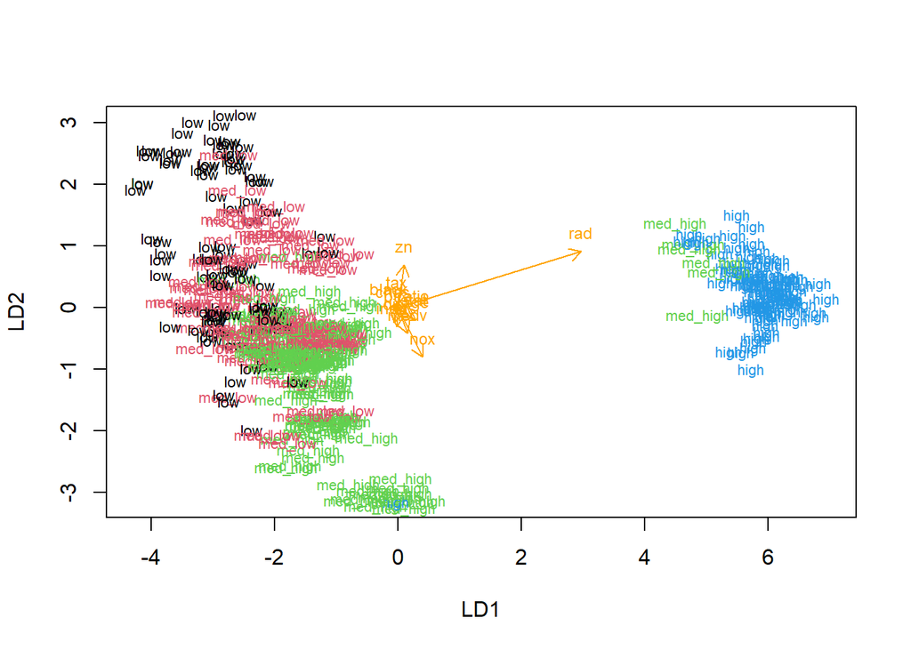

```r
# the function for lda biplot arrows
lda.arrows <- function(x, myscale = 1, arrow_heads = 0.1, color = "orange", tex = 0.75, choices = c(1,2)){
  heads <- coef(x)
  arrows(x0 = 0, y0 = 0,
         x1 = myscale * heads[,choices[1]],
         y1 = myscale * heads[,choices[2]], col=color, length = arrow_heads)
  text(myscale * heads[,choices], labels = row.names(heads),
       cex = tex, col=color, pos=3)
}

# target classes as numeric
classes <- as.numeric(train$crime)

# plot the lda results
plot(lda.fit, dimen = 2, col = classes, pch = classes)
lda.arrows(lda.fit, myscale = 1)
```

```r
# predict classes with test data
lda.pred <- predict(lda.fit, newdata = test)

# cross tabulate the results
table(correct = correct_classes, predicted = lda.pred$class)
```

```
##           predicted
## correct    low med_low med_high high
##   low       13      13        2    0
##   med_low    2      15        5    0
##   med_high   0       2       19    0
##   high       0       0        0   31
```

```r
# load MASS and Boston
library(MASS)
data('Boston')

# center and standardize variables
boston_scaled <- scale(Boston)

# euclidean distance matrix
dist_eu <- dist(boston_scaled)

# look at the summary of the distances
summary(dist_eu)
```

```
##    Min. 1st Qu.  Median    Mean 3rd Qu.    Max.
##  0.1343  3.4625  4.8241  4.9111  6.1863 14.3970
```

```r
# manhattan distance matrix
dist_man <- dist(boston_scaled, method = 'manhattan')

# look at the summary of the distances
summary(dist_man)
```

```
##    Min. 1st Qu.  Median    Mean 3rd Qu.    Max.
##  0.2662  8.4832 12.6090 13.5488 17.7568 48.8618
```

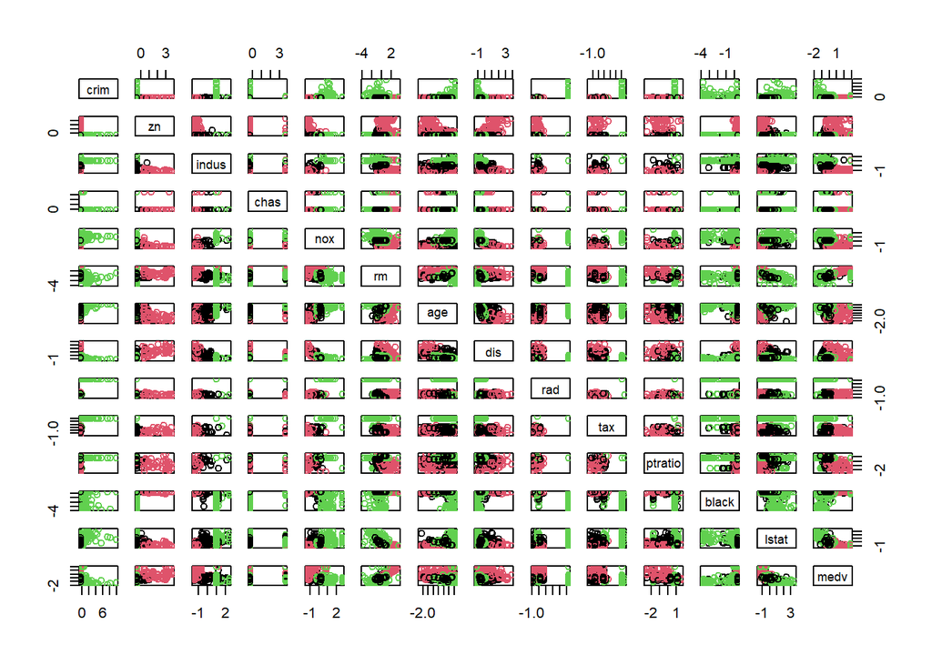

```r
# k-means clustering
km <-kmeans(boston_scaled, centers = 3)

# plot the Boston dataset with clusters
pairs(boston_scaled, col = km$cluster)
```